# Spatial Econometrics

# Introduction

The aims of this spatial project are creating visualization of the zomato dataset using India Maps and building model for spatial dependence. Our dataset is from kaggle (https://www.kaggle.com/shrutimehta/zomato-restaurants-data?select=zomato.csv). In the dataset there are 21 variables which consist of 1. Restaurant ID Identification number

2. Restaurant name Name of the restaurant
3. Country code There are 15 countries in the dataset. There are India, Australia, Brazil, Canda, Indonesia, New Zealand, Phillipines, Qatar, Singapore, South Africa, Sri Lanka, Turkey, UAE, United Kingdom ,and United States.
4. City City name of the restaurants
5. Address Address of the restaurants
6. Locality Short address of the restaurant
7. Locality Verbose Long address of the restaurant
8. Longitude
9. Latitude
10. Cuisines Types of cuisines served
11. Average Cost Per Two Average costs if two people visit to restaurant
12. Currency
13. Has Table Booking Can we book tables in Restaurant? Yes/No
14. Has Online Delivery Can we have online delivery ? Yes/No
15. Is Delivering Now Is the restaurant delivering food now? Yes/No
16. Switch to order menu Switch to order menu ? Yes/ No
17. Price range Categorized price between 1-4
18. Aggregate rating Categorizing ratings between 1-5
19. Rating color Different colors representing customer ratings
20. Rating text Different rating from customers: Not rated, Poor, Average, Good, Very Good, and Excellent.
21. Votes Number of votes received by restaurants from customers

```r
#setwd("C:/Users/Adinda Rizky Herawat/Dropbox/Spring Semester 2020_2021/2. Spatial Econometrics in R/Project/data")
#setwd("C:/Users/PC-CATHERINE/Dropbox/My PC (LAPTOP-C7FBOJ3B)/Downloads/Project")
zomato <- read.csv("data/zomato.csv",sep=",")
country.code <- read.csv2("data/countrycode.csv",sep=",")
names(country.code)<- c("Code","Country")
city_centroid <- read.csv("data/Indian Cities Database.csv",sep=",")
```

# Preparation Dataset

In this part we will explain that we will not use all the observations in the dataset. We would like to focus on one country only.

```r
# Identifying country based on country code
zomatodata <- merge(zomato, country.code, by.x="Country.Code", by.y="Code", all.x=TRUE, all.y=FALSE)
zomatodata <- merge(zomatodata, city_centroid, by.x="City", by.y="City", all.x=TRUE, all.y=FALSE)

# Checking number of countries
unique(zomatodata$Country) # 15 countries
```

```
##  [1] "UAE"            "India"          "United States"  "Turkey"
##  [5] "Australia"      "New Zealand"    "Indonesia"      "United Kingdom"
##  [9] "Brazil"         "South Africa"   "Canada"         "Sri Lanka"
## [13] "Qatar"          "Phillipines"    "Singapore"
```

```r
zomatodata %>%
  group_by(Country) %>%
  summarise(n())
```

```
## # A tibble: 15 x 2
##    Country        `n()`
##    <chr>          <int>
##  1 Australia         24
##  2 Brazil            60
##  3 Canada             4
##  4 India           8672
##  5 Indonesia         21
##  6 New Zealand       40
##  7 Phillipines       22
##  8 Qatar             20
##  9 Singapore         20
## 10 South Africa      60
## 11 Sri Lanka         20
## 12 Turkey            34
## 13 UAE               60
## 14 United Kingdom    80
## 15 United States    434
```

Based on the result above, among those 15 countries, India is the highest number of observations in the dataset. Therefore, we would like to analyze for the following analysis with India data only.

```r
library(geosphere)
# India
zomatoindia <- zomatodata %>% filter(Country=="India")
zomatoindia$City <- trimws(zomatoindia$City, which = c("both"))
city_centroid$City <- trimws(city_centroid$City, which = c("both"))

# library(lwgeom) #additional dependency
#
# st_distance(support.sf[1:5,],support.sf[1:5,])

zomatoindia$dist <-distHaversine(zomatoindia[,c('Longitude', 'Latitude')], zomatoindia[,c('Long','Lat')])
# sum(is.na(zomatoindia$dist))
zomatoindia <- na.omit(zomatoindia)



zomatoindia$Cafe <- factor(ifelse(grepl("Cafe|Beverages",zomatoindia$Cuisines),1,0))
zomatoindia$North_Indian <- factor(ifelse(grepl("North_Indian",zomatoindia$Cuisines),1,0))
zomatoindia$Continental <- factor(ifelse(grepl("Continental",zomatoindia$Cuisines),1,0))
zomatoindia$South_Indian <- factor(ifelse(grepl("South Indian|Chettinad",zomatoindia$Cuisines),1,0))
zomatoindia$Desserts <- factor(ifelse(grepl("Desserts|Mithai",zomatoindia$Cuisines),1,0))
zomatoindia$Fast_Food <- factor(ifelse(grepl("Fast Food|Finger Food",zomatoindia$Cuisines),1,0))
zomatoindia$Lebanese <- factor(ifelse(grepl("Lebanese",zomatoindia$Cuisines),1,0))
zomatoindia$Italian <- factor(ifelse(grepl("Italian",zomatoindia$Cuisines),1,0))
zomatoindia$American <- factor(ifelse(grepl("American",zomatoindia$Cuisines),1,0))
zomatoindia$Mediterranean <- factor(ifelse(grepl("Mediterranean",zomatoindia$Cuisines),1,0))
zomatoindia$Thai <- factor(ifelse(grepl("Thai",zomatoindia$Cuisines),1,0))
zomatoindia$Hyderabadi <- factor(ifelse(grepl("Hyderabadi",zomatoindia$Cuisines),1,0))
zomatoindia$Lucknowi <- factor(ifelse(grepl("Lucknowi",zomatoindia$Cuisines),1,0))
zomatoindia$Street_Food <- factor(ifelse(grepl("Street Food",zomatoindia$Cuisines),1,0))
zomatoindia$French <- factor(ifelse(grepl("French",zomatoindia$Cuisines),1,0))
zomatoindia$Japanese <- factor(ifelse(grepl("Japanese|Sushi",zomatoindia$Cuisines),1,0))
zomatoindia$Nepalese <- factor(ifelse(grepl("Nepalese",zomatoindia$Cuisines),1,0))
zomatoindia$Maharashtrian <- factor(ifelse(grepl("Maharashtrian",zomatoindia$Cuisines),1,0))

zomatoindia$Mughlai <- factor(ifelse(grepl("Mughlai",zomatoindia$Cuisines),1,0))
zomatoindia$Gujarati <- factor(ifelse(grepl("Gujarati",zomatoindia$Cuisines),1,0))
zomatoindia$Kashmiri <- factor(ifelse(grepl("Kashmiri",zomatoindia$Cuisines),1,0))
zomatoindia$Kerala <- factor(ifelse(grepl("Kerala",zomatoindia$Cuisines),1,0))
zomatoindia$Biryani <- factor(ifelse(grepl("Biryani",zomatoindia$Cuisines),1,0))
zomatoindia$Middle_Eastern <- factor(ifelse(grepl("Middle Eastern",zomatoindia$Cuisines),1,0))
zomatoindia$Bakery <- factor(ifelse(grepl("Bakery",zomatoindia$Cuisines),1,0))
zomatoindia$Seafood <- factor(ifelse(grepl("Seafood",zomatoindia$Cuisines),1,0))
zomatoindia$Mexican <- factor(ifelse(grepl("Mexican",zomatoindia$Cuisines),1,0))
zomatoindia$Bengali <- factor(ifelse(grepl("Bengali",zomatoindia$Cuisines),1,0))











# movies_agg<-merge(zomatoindia, ratings, by="movieId")
# movies_agg<-aggregate(movies_agg[,4:22], list(movies_agg$movieId), mean)
# movies_agg<-merge(zomatoindia[,1:2],movies_agg, by.x  ="movieId", by.y="Group.1")
# movies_agg<-within(movies_agg, rm(userId, timestamp))

# Preparation Dataset
zomatoindia$Country.Code <- NULL
zomatoindia$Restaurant.ID <- NULL
zomatoindia$Restaurant.Name <- NULL
zomatoindia$Address <- NULL
# #zomatoindia$City <- NULL
# zomatoindia$Longitude <- NULL
# zomatoindia$Latitude <- NULL
# zomatoindia$Country <- NULL
# #zomatoindia$Locality <- NULL
#zomatoindia$Locality.Verbose <- NULL
#zomatoindia$Cuisines <- NULL


#zomatoindia <- zomatoindia[,c(11:22)]
# zomatoindia$Currency <- NULL
# zomatoindia$Country <- NULL

zomatoindia$Has.Table.booking <- factor(zomatoindia$Has.Table.booking,
                                        levels=c("No","Yes"), ordered=FALSE)

zomatoindia$Has.Online.delivery <- factor(zomatoindia$Has.Online.delivery,
                                          levels=c("No","Yes"), ordered=FALSE)

zomatoindia$Is.delivering.now <- factor(zomatoindia$Is.delivering.now,
                                        levels=c("No","Yes"), ordered=FALSE)

zomatoindia$Switch.to.order.menu <- factor(zomatoindia$Switch.to.order.menu,
                                           levels=c("No","Yes"), ordered=FALSE)

zomatoindia$Price.range <- factor(zomatoindia$Price.range, levels=c(1,2,3,4),
                                  ordered=TRUE)

zomatoindia$Aggregate.rating <- as.numeric(as.character(zomatoindia$Aggregate.rating))

zomatoindia$Rating.color <- factor(zomatoindia$Rating.color,
                                   levels=c("Red","Orange","White",
                                            "Yellow","Green","Dark Green"))

zomatoindia$Rating.text <- factor(zomatoindia$Rating.text,
                                  levels=c("Not rated","Poor","Average",
                                           "Good", "Very Good", "Excellent"))
```

Now that we have added all the variables we require and have prepared the dataset, lets start with some visualisations to understand the dataset better.

# Reading maps

Below we would like to show maps based on the administative area

```r
ind_adm0 <- readOGR("data/IND_adm0")
ind_adm1 <-readOGR("data/IND_adm1")
ind_adm2 <- readOGR("data/IND_adm2")
ind_adm3 <- readOGR("data/IND_adm3")
ind_adm4 <- readOGR("data/IN_cities")
# changing projections
adm0 <- spTransform(ind_adm0, CRS("+proj=longlat +datum=NAD83"))
adm1 <- spTransform(ind_adm1, CRS("+proj=longlat +datum=NAD83"))
adm2 <- spTransform(ind_adm2, CRS("+proj=longlat +datum=NAD83"))
adm3 <- spTransform(ind_adm3, CRS("+proj=longlat +datum=NAD83"))
adm4 <- spTransform(ind_adm4, CRS("+proj=longlat +datum=NAD83"))
```

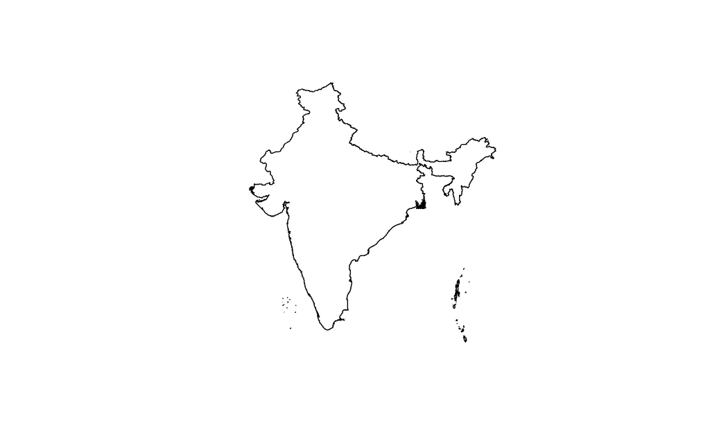

```r
plot(adm0)
```

This plot only show the India maps

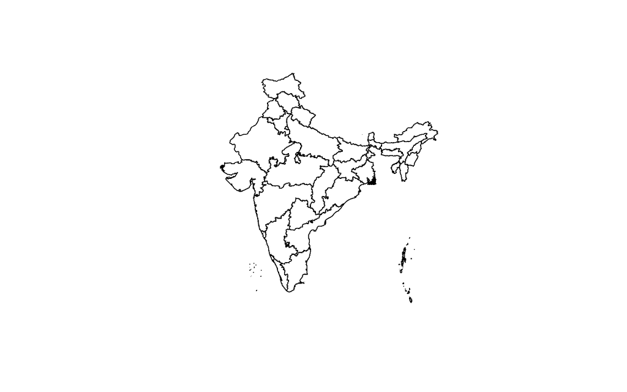

```r
plot(adm1)
```

This plot shows India maps with dividing by provinces

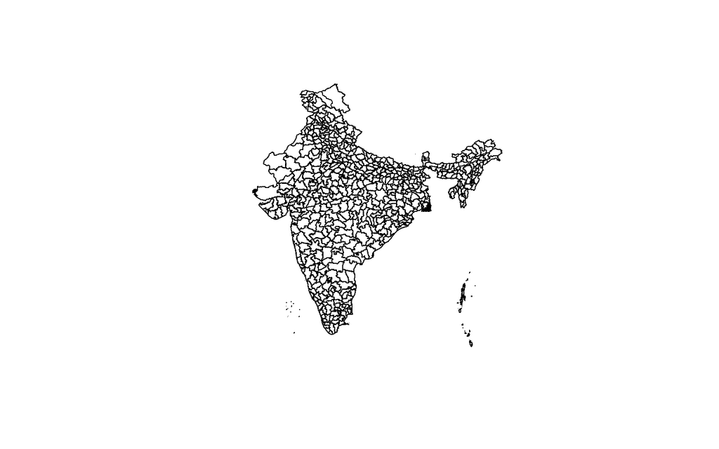

```r
plot(adm2)
```

This plot shows India maps with dividing by cities

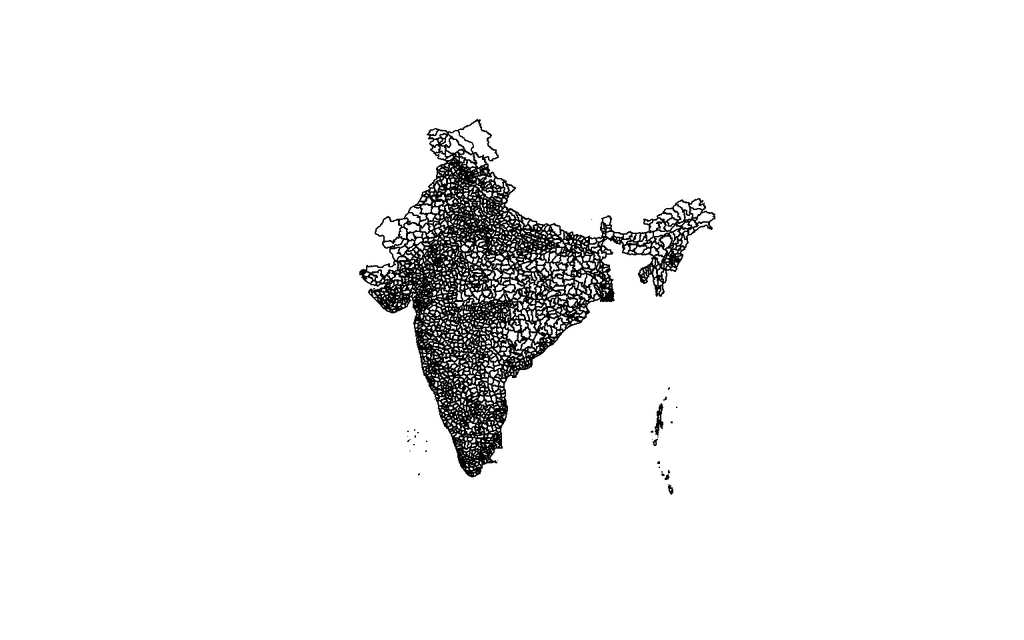

```r
plot(adm3)
```

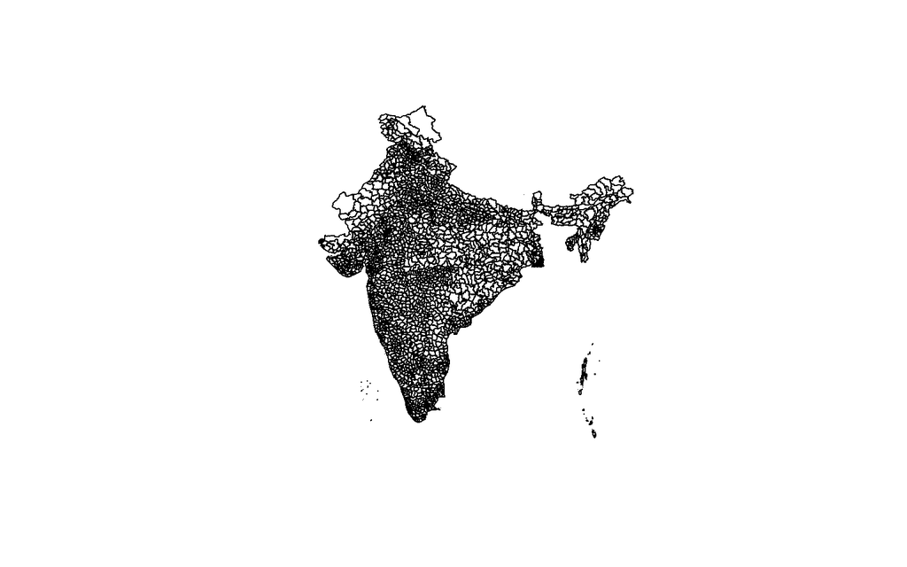

```r
plot(adm4)
```

Awe can see we have the shape files on the country-level, state-level, district-level and city/town - level.

# Visualization

This plot below shows India maps with information of state names

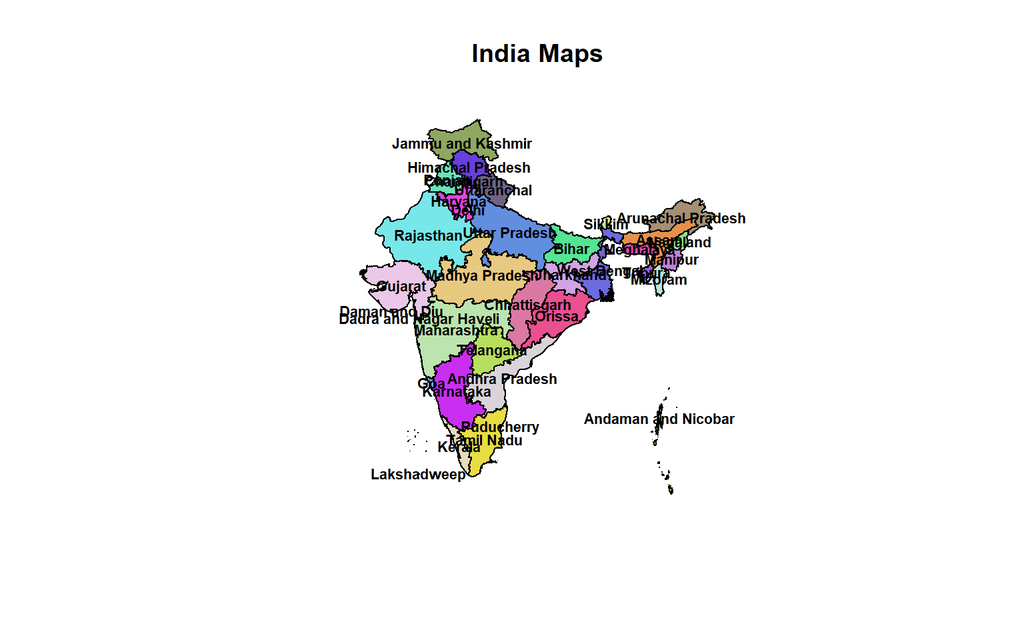

```r
# information about the province
adm_info <- read.csv2("data/IND_adm1/IND_adm1.csv",sep=",")
# extracting database from shapefile
prov.df <- as.data.frame(adm1)
myColor <- randomcoloR::distinctColorPalette(k = 38)
plot(adm1, col=myColor)
# labels of provincial names
crds.adm1 <- coordinates(adm1)
text(crds.adm1, label=prov.df$NAME_1, cex=0.7, font=2)
title(main="India Maps")
```

# Plotting based on certain variables

```r
summary(zomatoindia$Aggregate.rating)
```

```
##    Min. 1st Qu.  Median    Mean 3rd Qu.    Max.
##   0.000   2.300   3.100   2.549   3.600   4.900
```

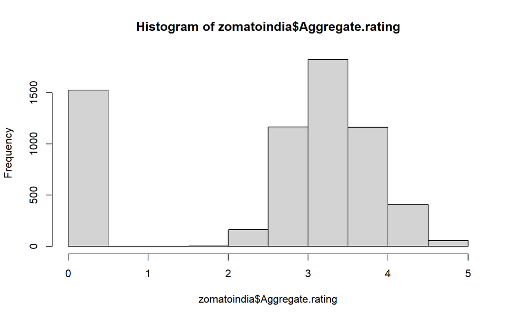

```r
hist(zomatoindia$Aggregate.rating)
```

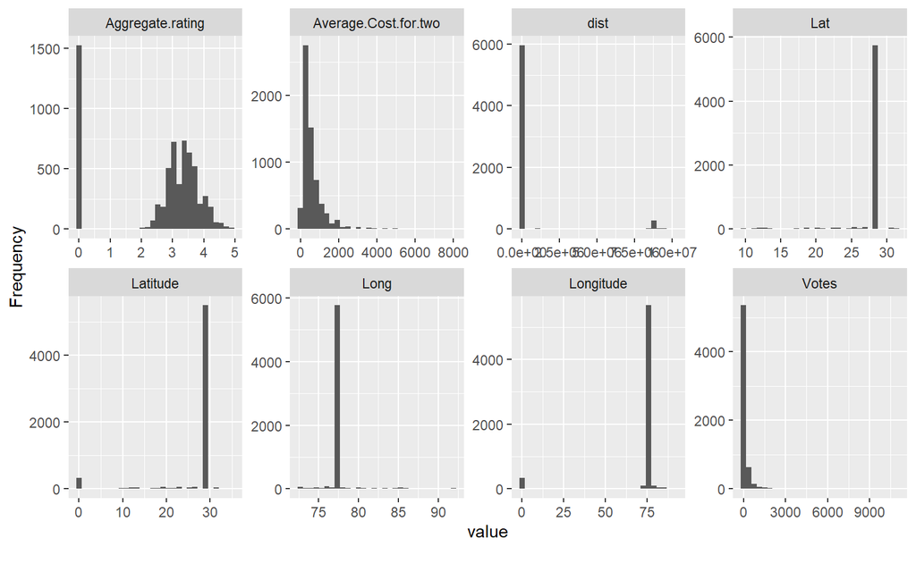

```r
library(DataExplorer)

plot_histogram(zomatoindia)
```

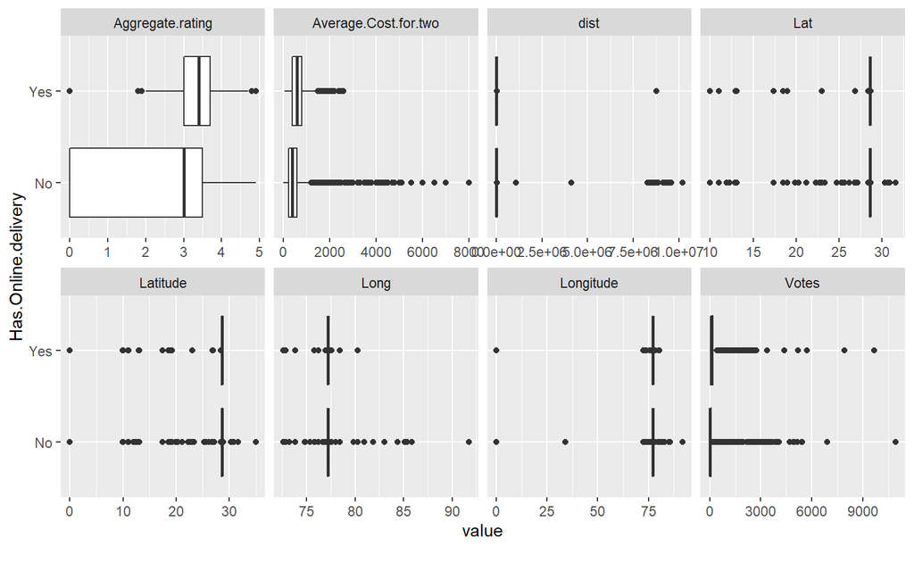

```r
plot_boxplot(zomatoindia, by = c("Has.Online.delivery"))
```

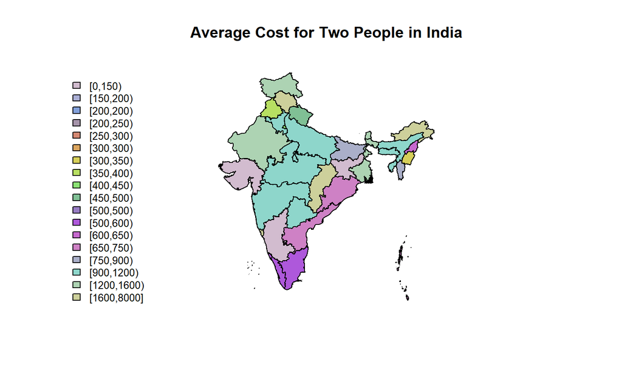

```r
intervals <- 18

myColor2 <- randomcoloR::distinctColorPalette(k =9)
#myColor2 <-colorRampPalette(c("red","yellow","springgreen","royalblue"))

classes<-classIntervals(zomatoindia$Average.Cost.for.two, intervals)#, style="fixed",
          #fixedBreaks=c(0, 1000, 2000, 3000, 4000, 5000, 6000, 7000, 8000))

color.table<-findColours(classes, myColor2)

plot(adm1, col=color.table)

legend("bottomleft", legend=names(attr(color.table, "table")),
fill=attr(color.table, "palette"), cex=0.8, bty="n")

title(main="Average Cost for Two People in India")
```

We see the majority of the states having the price range of 0-1000 INR for the average cost for two people. From the graph, we can see that few states which are mostly in western sides and two states on the east have quite higher value of average cost for two people.

# Maps with points based on aggregate rating variable

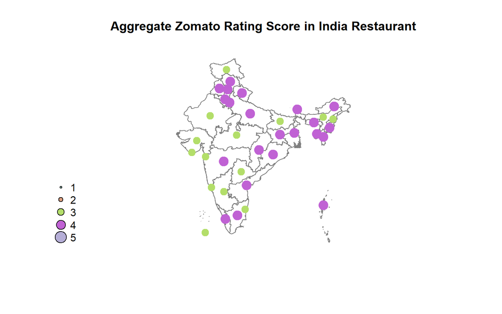

```r
brks<-c(1,2,3,4,5)
size<-brks/2

#plot(adm0, border="grey90")
plot(adm1, border="grey50")
#cols=brewer.pal(7, "Reds")
cols= randomcoloR::distinctColorPalette(k = 5)

points(crds.adm1, col=cols[findInterval(zomatoindia$Aggregate.rating, brks)],
cex=size[findInterval(zomatoindia$Aggregate.rating, brks)], pch=21, bg=cols[findInterval(zomatoindia$Aggregate.rating, brks)])

legend("bottomleft", legend=brks, pt.bg=cols, pt.cex=size, bty="n", pch=21)
title(main="Aggregate Zomato Rating Score in India Restaurant")
```

In the plot below it will show the zomato rating score from customers in all states. It seems that most of customers gave score between 3 and 4.

# Plot for Delhi

New Delhi is the capital city in India and with this plot, we would like to remark the New Delhi in the India maps.

```r
# read shapefile directly to sf collection
pov.sf <- st_read("data/IND_adm2/IND_adm2.shp", stringsAsFactors = FALSE)
pov.sf <- st_transform(pov.sf, crs = "+proj=longlat +datum=NAD83")
pov.sf
```

```
## Simple feature collection with 594 features and 11 fields
## Geometry type: MULTIPOLYGON
## Dimension:     XY
## Bounding box:  xmin: 68.18625 ymin: 6.754256 xmax: 97.41516 ymax: 35.50133
## CRS:           +proj=longlat +datum=NAD83
## First 10 features:
##    ID_0 ISO NAME_0 ID_1              NAME_1 ID_2          NAME_2   TYPE_2
## 1   105 IND  India    1 Andaman and Nicobar    1 Andaman Islands District
## 2   105 IND  India    1 Andaman and Nicobar    2 Nicobar Islands District
## 3   105 IND  India    2      Andhra Pradesh    3       Anantapur District
## 4   105 IND  India    2      Andhra Pradesh    4        Chittoor District
## 5   105 IND  India    2      Andhra Pradesh    5        Cuddapah District
## 6   105 IND  India    2      Andhra Pradesh    6   East Godavari District
## 7   105 IND  India    2      Andhra Pradesh    7          Guntur District
## 8   105 IND  India    2      Andhra Pradesh    8         Krishna District
## 9   105 IND  India    2      Andhra Pradesh    9         Kurnool District
## 10  105 IND  India    2      Andhra Pradesh   10         Nellore District
##    ENGTYPE_2 NL_NAME_2            VARNAME_2                       geometry
## 1   District      <NA>                 <NA> MULTIPOLYGON (((93.64841 14...
## 2   District      <NA>                 <NA> MULTIPOLYGON (((92.78778 9....
## 3   District      <NA> Anantpur, Ananthapur MULTIPOLYGON (((77.69 15.17...
## 4   District      <NA>      Chitoor|Chittor MULTIPOLYGON (((78.47611 13...
## 5   District      <NA>                 <NA> MULTIPOLYGON (((78.94612 15...
## 6   District      <NA>                 <NA> MULTIPOLYGON (((82.31735 16...
## 7   District      <NA>                 <NA> MULTIPOLYGON (((80.78291 15...
## 8   District      <NA>               Kistna MULTIPOLYGON (((81.02792 15...
## 9   District      <NA>                 <NA> MULTIPOLYGON (((78.88907 16...
## 10  District      <NA>                 <NA> MULTIPOLYGON (((80.27458 13...
```

```r
pov.sf.centr <- st_centroid(pov.sf)
```

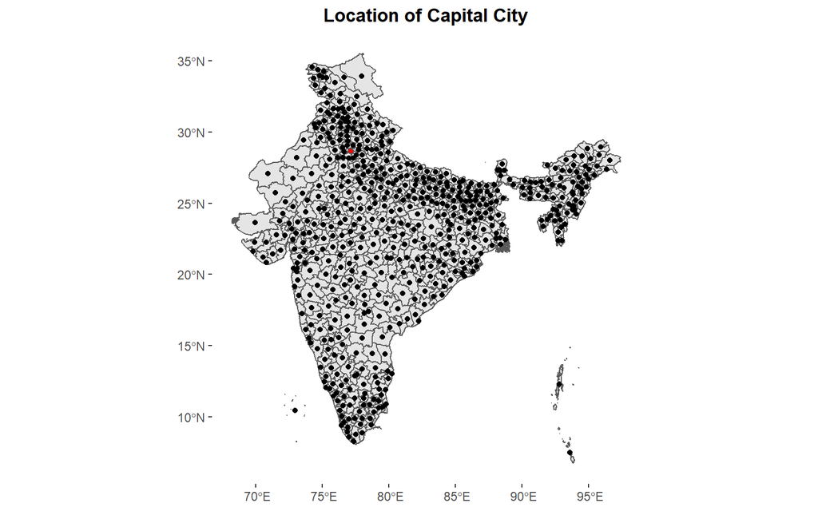

```r
ggplot()+
  geom_sf(pov.sf, mapping = aes(geometry=geometry))+
  geom_sf(pov.sf.centr, mapping = aes(geometry=geometry)) +
  geom_sf(pov.sf %>% filter(NAME_1 =='Delhi'),
          mapping = aes(geometry=geometry), fill = "red")+
  ggtitle("Location of Capital City")+
  theme(legend.position = "none",
    plot.title = element_text(hjust=0.5, face="bold"),
    plot.subtitle = element_text(hjust=0.5, face="bold"),
    panel.grid.major = element_line(colour = "white"),
    panel.grid.major.x = element_line(size=1, colour="white"),
    panel.grid.minor.y = element_line(size = 1, colour = "white"),
    panel.background = element_rect(fill = "white", colour = "white"))
```

Here is the larger version of New Delhi

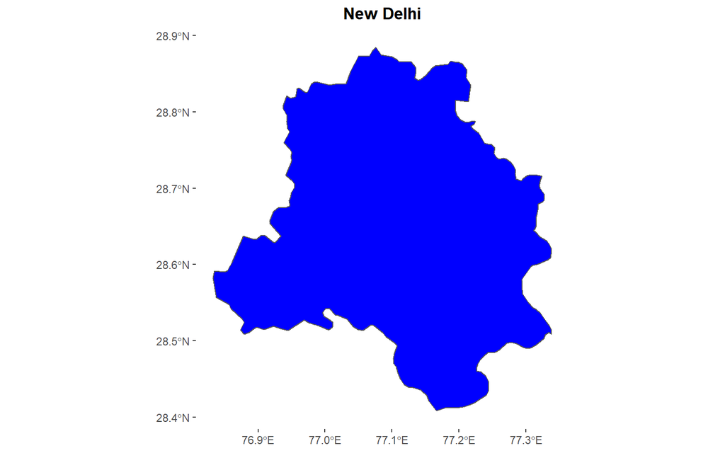

```r
delhi.pov.sf <- pov.sf %>% filter(NAME_1=='Delhi')

ggplot() +
    geom_sf(delhi.pov.sf, mapping = aes(geometry=geometry), fill="blue") +
    ggtitle("New Delhi")+
    theme(legend.position = "none",
    plot.title = element_text(hjust=0.5, face="bold"),
    plot.subtitle = element_text(hjust=0.5, face="bold"),
    panel.grid.major = element_line(colour = "white"),
    panel.grid.major.x = element_line(size=1, colour="white"),
    panel.grid.minor.y = element_line(size = 1, colour = "white"),
    panel.background = element_rect(fill = "white", colour = "white"))
```

# Location of the restaurant

Lets plot the location of restaurants in Delhi:

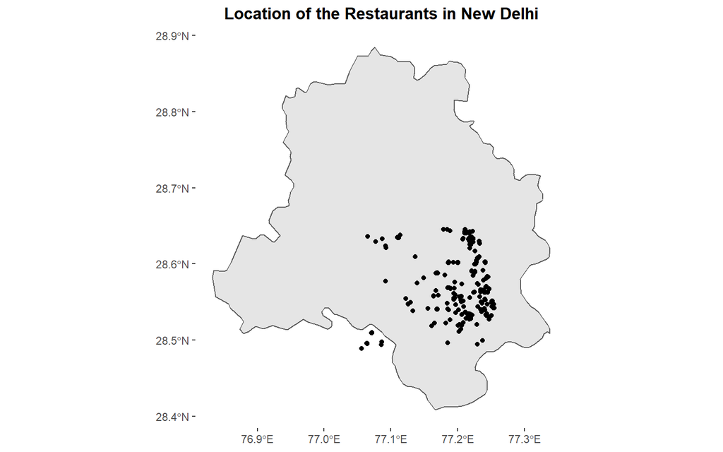

```r
delhi_box <- getbb("New Delhi, India")

# Get Restaurant information in the New Delhi
#https://wiki.openstreetmap.org/wiki/Map_features

restaurant.sf = opq(delhi_box) %>% # limit search to the bounding box
  add_osm_feature(key='amenity', value = 'restaurant') %>%
  osmdata_sf() # save the data into sf collection

ggplot() +
  geom_sf(delhi.pov.sf, mapping = aes(geometry = geometry))+
  geom_sf(restaurant.sf$osm_points, mapping = aes(geometry = geometry)) +
  ggtitle("Location of the Restaurants in New Delhi") +
  theme(legend.position = "none",
  plot.title = element_text(hjust=0.5, face="bold"),
  plot.subtitle = element_text(hjust=0.5, face="bold"),
  panel.grid.major = element_line(colour = "white"),
  panel.grid.major.x = element_line(size=1, colour="white"),
  panel.grid.minor.y = element_line(size = 1, colour = "white"),
  panel.background = element_rect(fill = "white", colour = "white"))
```

In New Delhi, We see most of the restaurants are located towards south eastern of the states this is because in the descriptions of the restaurant fast food chains are not included. Furthermore, India known to have a lot of street food avenues which are probably more ubiquitous than restaurants. That’s why there is cluster of restaurants in the one side of the city.

# Public Spaces in New Delhi

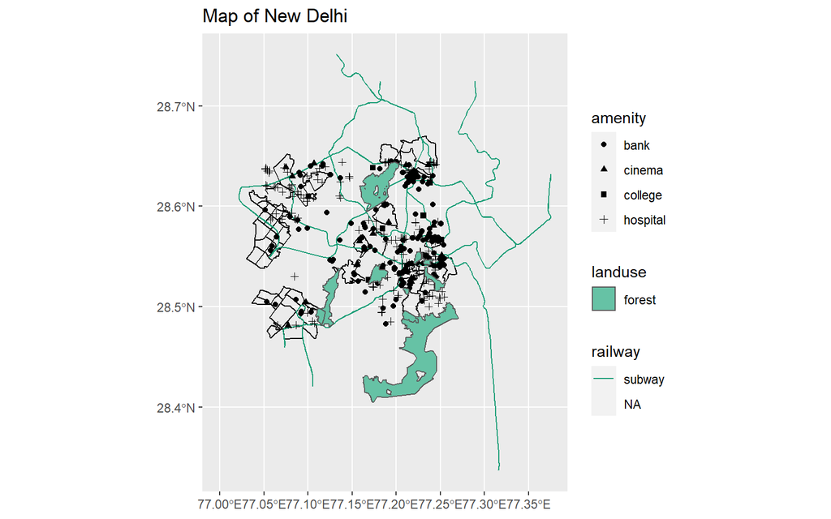

```r
city_delhi.sf <- opq(delhi_box) %>%
  add_osm_feature(key='admin_level', value='9') %>%
  osmdata_sf()

bus.sf <- opq(delhi_box) %>%
  add_osm_feature(key='amenity', value = 'bus_station') %>% osmdata_sf()

hospital.sf <- opq(delhi_box) %>%
  add_osm_feature(key='amenity', value = 'hospital') %>% osmdata_sf()

cinema.sf <- opq(delhi_box) %>%
  add_osm_feature(key='amenity', value = 'cinema') %>% osmdata_sf()

college.sf <- opq(delhi_box) %>%
  add_osm_feature(key='amenity', value = 'college') %>% osmdata_sf()

bank.sf <- opq(delhi_box) %>%
  add_osm_feature(key='amenity', value = 'bank') %>% osmdata_sf()

#temple.sf <- opq(delhi_box) %>%
#  add_osm_feature(key='building', value = 'temple') %>% osmdata_sf()

#mosque.sf <- opq(delhi_box) %>%
#  add_osm_feature(key='building', value = 'mosque') %>% osmdata_sf()

#church.sf <- opq(delhi_box) %>%
#  add_osm_feature(key='building', value = 'church') %>% osmdata_sf()

forest_delhi.sf = opq(bbox = "New Delhi India") %>%
  add_osm_feature(key = "landuse", value = "forest") %>%
  osmdata_sf()

tr <- opq(delhi_box) %>%
  add_osm_feature(key='route', value = 'bus')

su <- opq(delhi_box) %>%
  add_osm_feature(key='route', value = 'subway')

#merge them to one object
transport_delhi.sf = c(osmdata_sf(tr), osmdata_sf(su))

ggplot() +
  geom_sf(city_delhi.sf$osm_lines, mapping = aes(geometry=geometry))+
  geom_sf(transport_delhi.sf$osm_lines, mapping = aes(geometry=geometry,
                                                      col = railway)) +
  geom_sf(hospital.sf$osm_points, mapping = aes(geometry=geometry,
                                                shape=amenity)) +
  geom_sf(bank.sf$osm_points, mapping = aes(geometry=geometry,
                                            shape= amenity)) +
  geom_sf(college.sf$osm_points, mapping = aes(geometry=geometry,
                                                  shape= amenity)) +
  geom_sf(cinema.sf$osm_points, mapping = aes(geometry=geometry,
                                              shape= amenity)) +
  geom_sf(forest_delhi.sf$osm_multipolygons, mapping = aes(geometry=geometry,
                                                         fill = landuse)) +
#  geom_sf(temple.sf$osm_points, mapping = aes(geometry=geometry,
#                                                  key= building)) +
#  geom_sf(mosque.sf$osm_points, mapping = aes(geometry=geometry,
#                                                  key= building)) +
#  geom_sf(mosque.sf$osm_points, mapping = aes(geometry=geometry,
#                                                  key= building)) +
  scale_color_brewer(palette = "Dark2")+
  scale_fill_brewer(palette = "Set2")+
  labs(title = "Map of New Delhi")
```

```r
  #theme_minimal()
```

This is another version of the maps using ggmap function

```r
delhi_map <- get_map(getbb("New Delhi India"),  maptype = "toner-background")
```

```
## maptype = "toner-background" is only available with source = "stamen".
```

```
## resetting to source = "stamen"...
```

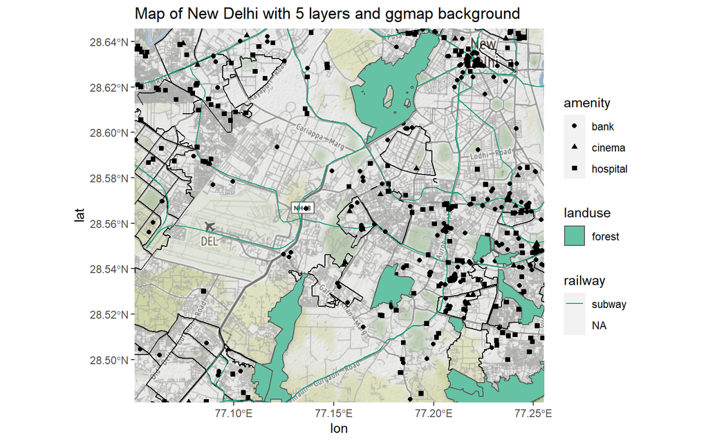

```r
#ggmap(delhi_map)

ggmap(delhi_map) +
  geom_sf(city_delhi.sf$osm_lines,
          mapping = aes(geometry=geometry), inherit.aes = FALSE)+
  geom_sf(transport_delhi.sf$osm_lines, mapping = aes(geometry=geometry,
          col = railway), inherit.aes = FALSE)+
  geom_sf(hospital.sf$osm_points, mapping = aes(geometry=geometry,
         shape=amenity), inherit.aes = FALSE) +
  geom_sf(bank.sf$osm_points, mapping = aes(geometry=geometry,
                              shape= amenity), inherit.aes = FALSE) +
  #geom_sf(university.sf$osm_points, mapping = aes(geometry=geometry,
                              #shape= amenity), inherit.aes = FALSE) +
  geom_sf(cinema.sf$osm_points, mapping = aes(geometry=geometry,
                                shape= amenity), inherit.aes = FALSE) +
  geom_sf(forest_delhi.sf$osm_multipolygons, mapping = aes(geometry=geometry,
                                  fill = landuse), inherit.aes = FALSE) +
  scale_color_brewer(palette = "Dark2")+
  scale_fill_brewer(palette = "Set2")+
  labs(title = "Map of New Delhi with 5 layers and ggmap background")
```

From the maps above and observing Delhi, we have assumed that the restaurants are present in a cluster more or less, and next we want to see if there is a correlation between space and the Aggregate Rating of a restaurant on Zomato.

# Spatial Dependence

We have chosen to apply the Spatial Dependance model for our dataset. So, first we start with creating the spatial weights matrix:

```r
# preparing spatial weights matrix
crds.adm4 <- coordinates(adm4)
cont.nb<-poly2nb(as(adm4, "SpatialPolygons"))
cont.listw<-nb2listw(cont.nb, style="W", zero.policy = T)
print(cont.listw,zero.policy = TRUE)# summary of matrix
```

```
## Characteristics of weights list object:
## Neighbour list object:
## Number of regions: 2340
## Number of nonzero links: 13106
## Percentage nonzero weights: 0.2393528
## Average number of links: 5.600855
## 39 regions with no links:
## 0 1 2 15 46 52 57 73 75 80 81 351 355 358 361 390 427 428 432 433 452 453 510 512 849 936 937 938 939 940 953 1333 1336 1342 1858 1860 1868 1873 1905
##
## Weights style: W
## Weights constants summary:
##      n      nn   S0       S1       S2
## W 2301 5294601 2301 855.9928 9433.895
```

```r
#https://stat.ethz.ch/pipermail/r-help/2007-November/146391.html
#https://community.rstudio.com/t/error-in-nb2listw-w-nb-style-w-empty-neighbour-sets-found/96922/3
```

Next, we move on to preparing the formula for our model. Now, on checking the variables, we have made sure that it doesn’t create a zero or singular matrix in the spatial weights matrix, the inversion of that matrix gives an error saying that a singular matrix cannot be inverted. So by taking the variables one by one, we have eliminated all the variables which were causing is to have a singular matrix. After this step wise elimination, we are left with the following variables: 1) Average.Cost.for.Two 2) Price.range 3) dist 4) Cafe 5) Desserts 6) Fast_Food 7) Has.Table.booking 8) Has.Online.delivery

```r
# preparing model
form <- Aggregate.rating ~ Average.Cost.for.two + Price.range + dist + Cafe  + Desserts + Fast_Food + Has.Table.booking + Has.Online.delivery

# variable switch to order menu doesn't work because this variable should be contain "Yes" or "No" but this variable only contains "No". then it is useless to use this variable
```

## Linear Model

We start with linear model with these variables:

```r
zomatoindia1 <- zomatoindia[1:2340,]

model.lm <- lm(form, data=zomatoindia1)
summary(model.lm)
```

```
##
## Call:
## lm(formula = form, data = zomatoindia1)
##
## Residuals:
##     Min      1Q  Median      3Q     Max
## -4.2896 -0.5183  0.3179  0.8684  2.9680
##
## Coefficients:
##                          Estimate Std. Error t value Pr(>|t|)
## (Intercept)             2.701e+00  1.329e-01  20.328  < 2e-16 ***
## Average.Cost.for.two    3.204e-04  1.177e-04   2.722  0.00654 **
## Price.range.L           1.060e+00  1.904e-01   5.570 2.84e-08 ***
## Price.range.Q          -3.580e-01  8.894e-02  -4.025 5.88e-05 ***
## Price.range.C          -1.147e-01  6.022e-02  -1.904  0.05704 .
## dist                   -6.997e-08  1.213e-08  -5.767 9.15e-09 ***
## Cafe1                   5.481e-01  8.330e-02   6.580 5.80e-11 ***
## Desserts1               4.776e-01  8.169e-02   5.846 5.73e-09 ***
## Fast_Food1              1.210e-01  6.237e-02   1.939  0.05256 .
## Has.Table.bookingYes   -3.146e-01  9.655e-02  -3.258  0.00114 **
## Has.Online.deliveryYes  4.957e-01  6.170e-02   8.035 1.47e-15 ***
## ---
## Signif. codes:  0 '***' 0.001 '**' 0.01 '*' 0.05 '.' 0.1 ' ' 1
##
## Residual standard error: 1.249 on 2329 degrees of freedom
## Multiple R-squared:  0.2605, Adjusted R-squared:  0.2573
## F-statistic: 82.03 on 10 and 2329 DF,  p-value: < 2.2e-16
```

From the summary, we see that almost all the variables are significant with a 10% CI, but with 5% CI we find that Average cost, price range, Cafe , Desserts , ‘Has table booking yes’ and ‘Has online delivery yes’ are significant in determining average rating of a restaurant in Zomato. It gives us an idea that when it comes to rating of a restaurant, not only the price,distance and delivery option are significant, but also the type of the restaurants. But before we further analyse the result, lets do some more test to find out if we have autocorrelation in the residuals and if we should include some non linear variables:

```r
# diagnostics of linear model
bptest(model.lm)
```

```
##
##  studentized Breusch-Pagan test
##
## data:  model.lm
## BP = 330.39, df = 10, p-value < 2.2e-16
```

```r
# Ho: Homocscedasticity
# H1: Heteroscedasticityy

# Our p-value is < 2.2e-16 which is below 5%, therefore we would like to reject H0 then our conclusion is our linear model has Homocscedasticity.
```

Th p-value from the Breusch Pagan test suggests that we have to reject the null hypothesis of homosckedasticity as the residuals seem to autocorrelated. This means that our R -squares (25%) and the p-value might be inflated. Next lest do Ramsey’s resset test:

```r
# Ramsey's test for functional form
# H1: when non-linear variables (like powers of the variables) should be included as model is mis-specified
resettest(model.lm, power=2, type="regressor")
```

```
##
##  RESET test
##
## data:  model.lm
## RESET = 7.8083, df1 = 2, df2 = 2327, p-value = 0.0004171
```

```r
# Our p-value is 0.0004171 which is below 5%, therefore we would like to reject H0 then our conclusion is non-linear variables like powers of the variables should be included
```

Next, lets move on to plotting the residuals to see the distribution across the country:

```r
# Spatial distribution of OLS residuals
summary(model.lm$residuals)
```

```
##    Min. 1st Qu.  Median    Mean 3rd Qu.    Max.
## -4.2896 -0.5183  0.3179  0.0000  0.8684  2.9680
```

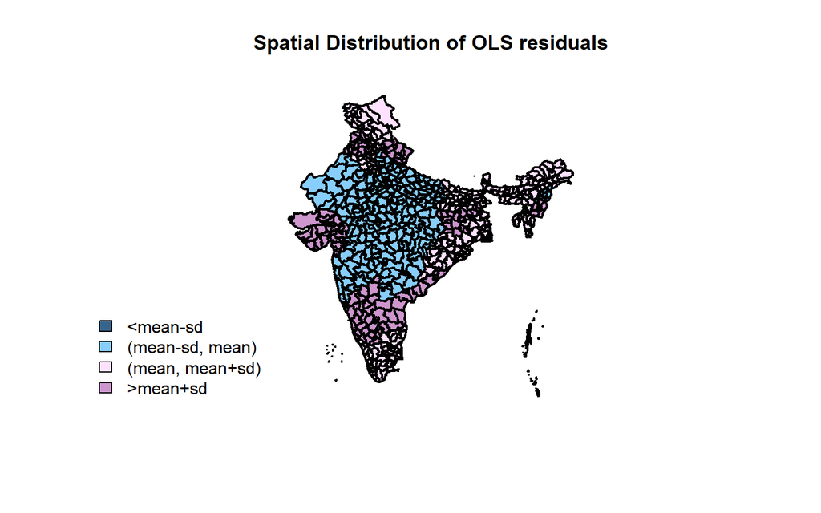

```r
res <- model.lm$residuals
brks<-c(min(res), mean(res)-sd(res), mean(res), mean(res)+sd(res), max(res))
cols<-c("steelblue4","lightskyblue","thistle1","plum3")

plot(adm1, col=cols[findInterval(res,brks)])
plot(adm2, add=TRUE, lwd=2)
title(main="Spatial Distribution of OLS residuals")
legend("bottomleft", legend=c("<mean-sd", "(mean-sd, mean)", "(mean, mean+sd)", ">mean+sd"), leglabs(brks1), fill=cols, bty="n")
```